# Does the Central Limit Theorem (CLT) apply to Exponential Probability Distributions (EPD)?

A simulation exercise

Darwin Reynell Nava

May 30, 2021

Abstract

## Overview

- **Background**: The CLT states that the distribution of sample means approximates a normal distribution as the sample size gets larger regardless of its distribution in the population.
- **Objectives**: Determine the properties of the distribution of the mean of 40 exponentials witn lambda=0.2. Determine that the EPD obtained follows the CTL.
- **Methods**: An statistical inference analysis via simulations in R.
- **Results**: The sample mean is 4.99 while the theoretical mean of the distribution is 5. The sample variance is 25,064 while to the theoretical variance of the distribution is 25. The distribution for a large collection of averages of 40 exponentials is approximately normal. However, the distribution of a large collection of random exponentials is exponential.
- **Conclusions**: the Central Limit Theorem (CLT) applies to Exponential Probability Distributions (EPD) too.

[Github link](https://github.com/darwinnava/Statistical_Inference_Project)

## Data processing

It is required to simulate a distribution of averages of 40 exponentials in R and compare it with the Central Limit Theorem. Lambda = 0.2 has been set for thousand (1000) simulations.

The properties of the distribution of the mean of 40 exponentials should be illustrated. Specifically,  
- The sample and theoretical means.  
- The sample and theoretical variances.  
- A distribution that should be approximately normal(here, focus on the difference between the distribution of a large collection of random exponentials and the distribution of a large collection of averages of 40 exponentials).

### Simulations

**Generate data for a distribution of 1000 averages of 40 random exponentials**

```r
sim_number <- 1000 # number of simulations
elem_number <- 40 # Number of elements in each exponential distribution
rate_parameter <- 0.2 # Rate parameter
set.seed(1) #
averages = NULL
variances = NULL
for (i in 1 : sim_number) averages = c(averages, mean(rexp(n=elem_number, rate = rate_parameter)))
set.seed(1) #
for (i in 1 : sim_number)  variances = c(variances, var(rexp(n=elem_number, rate = rate_parameter)))
```

**Generate data for a distribution of a large collection of random exponentials (1000 elements, lambda= 0.2)**

```r
set.seed(2)
large_collection <-  rexp(n=sim_number, rate = 0.2)
```

## Results

### Comparison between the Sample and Theoretical Means

```
## [1] "The sample mean: 4.99002520077716 | The Theoretical Mean (1/lambda): 5"
```

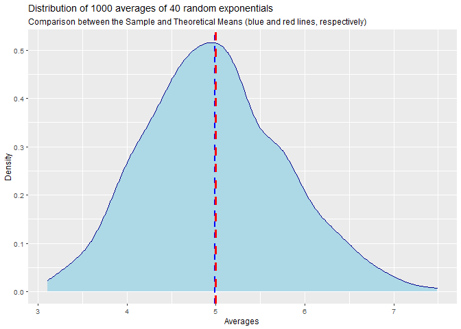

**Observations: Both values are similar. The sample mean of a distribution of 1000 averages of 40 random exponentials coincides with what is described by the CLT.**

### Comparison between the Sample and Theoretical Variances

```
## [1] "The mean of variances: 25.0645859581104 | The Theoretical variance (1/lambda^2): 25"
```

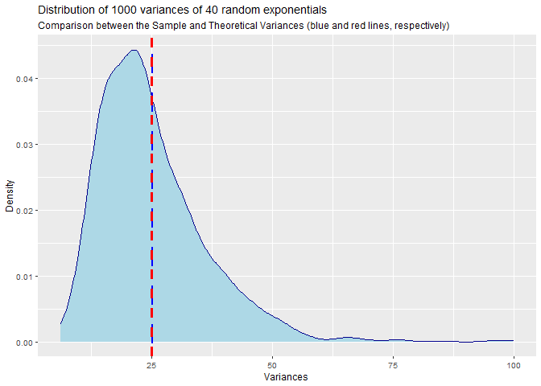

### Distribution

**Distribution of 1000 averages of 40 random exponentials versus Distribution of a large collection of random exponentials**

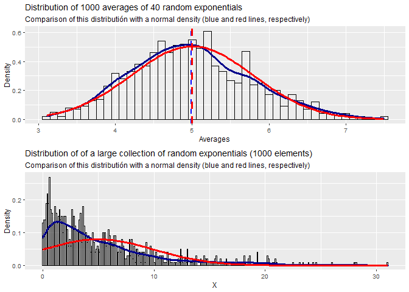

**Observations: The distribution for a large collection of averages of 40 exponentials is approximately normal. However, the distribution of a large collection of random exponentials is exponential.**

## Conclusions

the Central Limit Theorem (CLT) apply to Exponential Probability Distributions (EPD) too. The distribution of 1000 averages of 40 random exponentials simulated approximates a normal distribution regardless of its distribution in the population.  
end/final

## Appendix - Code

### Data processing

```r
library(dplyr)
library(ggplot2)
library(gridExtra)
```

### Simulations

```r
sim_number <- 1000 # number of simulations
elem_number <- 40 # Number of elements in each exponential distribution
rate_parameter <- 0.2 # Rate parameter
set.seed(1) #
averages = NULL
variances = NULL
for (i in 1 : sim_number) averages = c(averages, mean(rexp(n=elem_number, rate = rate_parameter)))
set.seed(1) #
for (i in 1 : sim_number)  variances = c(variances, var(rexp(n=elem_number, rate = rate_parameter)))
```

```r
head(averages)
head(variances)
length(averages)
length(variances)
```

```r
set.seed(2)
large_collection <-  rexp(n=sim_number, rate = 0.2)
```

```r
head(large_collection)
length(large_collection)
```

### Comparison between the Sample and Theoretical Means

```r
smean <- mean(averages) # the sample mean
tmean <- 1/rate_parameter # 1/lambda is mean in this kind of distribution
print(paste("The sample mean:", smean, "|", "The Theoretical Mean (1/lambda):", tmean))
```

```r
theme_set(theme_gray(base_size = 9))
ggplot(as.data.frame(averages), aes(x = averages)) + geom_density(color="darkblue", fill="lightblue")+geom_vline(aes(xintercept=mean(averages)), color="blue", linetype="dashed", size=1)+geom_vline(aes(xintercept=tmean), color="red", linetype="dashed", size=1.2)+ labs(title = "Distribution of 1000 averages of 40 random exponentials",subtitle = "Comparison between the Sample and Theoretical Means (blue and red lines, respectively)") + labs(x="Averages", y= "Density")
```

### Comparison between the Sample and Theoretical Variances

```r
svariance <- (mean(variances)) # the sample variance
tvariance <- 1/(rate_parameter^2) # 1/(lambda^2) is variance in this kind of distribution
print(paste("The mean of variances:", mean(variances), "|", "The Theoretical variance (1/lambda^2):", tvariance))
```

```r
theme_set(theme_gray(base_size = 9))
ggplot(as.data.frame(variances), aes(x = variances)) + geom_density(color="darkblue", fill="lightblue")+geom_vline(aes(xintercept=svariance), color="blue", linetype="dashed", size=1)+geom_vline(aes(xintercept=tvariance), color="red", linetype="dashed", size=1.2)+ labs(title = "Distribution of 1000 variances of 40 random exponentials",subtitle = "Comparison between the Sample and Theoretical Variances (blue and red lines, respectively)") + labs(x="Variances", y= "Density")
```

### Distribution of 1000 averages of 40 random exponentials versus Distribution of a large collection of random exponentials

```r
theme_set(theme_gray(base_size = 9))

plot1<- ggplot(as.data.frame(averages), aes(x = averages)) + geom_histogram(aes(y=..density..), colour="black", fill="white", alpha = .10, binwidth=0.1)+ geom_density(color="darkblue", size=1.2)+ stat_function(fun = dnorm, args = list(mean = 5, sd = 5/sqrt(40)), size=1.2, color="red") +  geom_vline(aes(xintercept=mean(averages)), color="blue", linetype="dashed",size=1)+geom_vline(aes(xintercept=tmean), color="red", linetype="dashed", size=1.2)+ labs(title = "Distribution of 1000 averages of 40 random exponentials",subtitle = "Comparison of this distributión with a normal density (blue and red lines, respectively)") + labs(x="Averages", y= "Density")

plot2<- ggplot(as.data.frame(large_collection), aes(x = large_collection)) + geom_histogram(aes(y=..density..), colour="black", fill="white", alpha = .10, binwidth=0.1)+ geom_density(color="darkblue", size=1.2)+ stat_function(fun = dnorm, args = list(mean = 5, sd = 5/sqrt(1)), size=1.2, color="red") + labs(title = "Distribution of of a large collection of random exponentials (1000 elements)",subtitle = "Comparison of this distributión with a normal density (blue and red lines, respectively)") + labs(x="X", y= "Density")

grid.arrange(plot1, plot2, nrow = 2)
```